# Отчет

Nikita Burlov

2024-02-10

### Statistical analysis

Diagnostic parameters were evaluated: sensitivity, specificity, positive and negative predictive value (PPV and NPV), positive and negative likelihood ratio (LR+ and LR-). Based on the literature data, a priors of sensitivity and specificity of the Wells score (67% and 90%, respectively) were used through the beta distribution (alpha1 = 12, beta1 = 6; alpha2 = 47, beta2 = 5) [doi: 10.1186/s13017-016-0078-1], then a posterior distribution was obtained based on our own data. After 10,000 iterations through LR+ and LR- post-test probability values (PPV and NPV) were obtained for each prevalence (pre-test probability from 1% to 99%), later we calculated estimate and 89% credible interval. For statistical processing, we used the open source software R version 4.2.2 (The R Foundation, http://www.R-project.org) with packages «tidyverse», «epiR», «gt», «ggplot2», «tidybayes», «ggdist».

### Results

Table 1. The two-by-two contingency table.

| **Test** | **Outcome** **+** | **Outcome** **-** | **Total** |  |
| --- | --- | --- | --- | --- |
| + | 429 | 38 |  | 467 |
| - | 33 | 367 | 400 |  |
| Total | 462 | 405 | 867 |  |

Our research data on test results and outcomes.

Table 2. Diagnostic characteristics.

| Parameters | Estimate | 95% CI |
| --- | --- | --- |
| Prevalence, % | 53.29 | 49.90 — 56.65 |
| Sensitivity, % | 92.86 | 90.11 — 95.03 |
| Specificity, % | 90.62 | 87.35 — 93.27 |
| PPV, % | 91.86 | 89.00 — 94.18 |
| NPV, % | 91.75 | 88.61 — 94.25 |
| LR+ | 9.897 | 7.304 — 13.41 |
| LR- | 0.079 | 0.057 — 0.11 |

PPV - positive predictive value, NPV - negative predictive value, LR+ - likelihood ratio positive, LR- - likelihood ratio negative, CI - confidence interval.

Figure 1. Priors and posteriors for sensitivity and specificity.

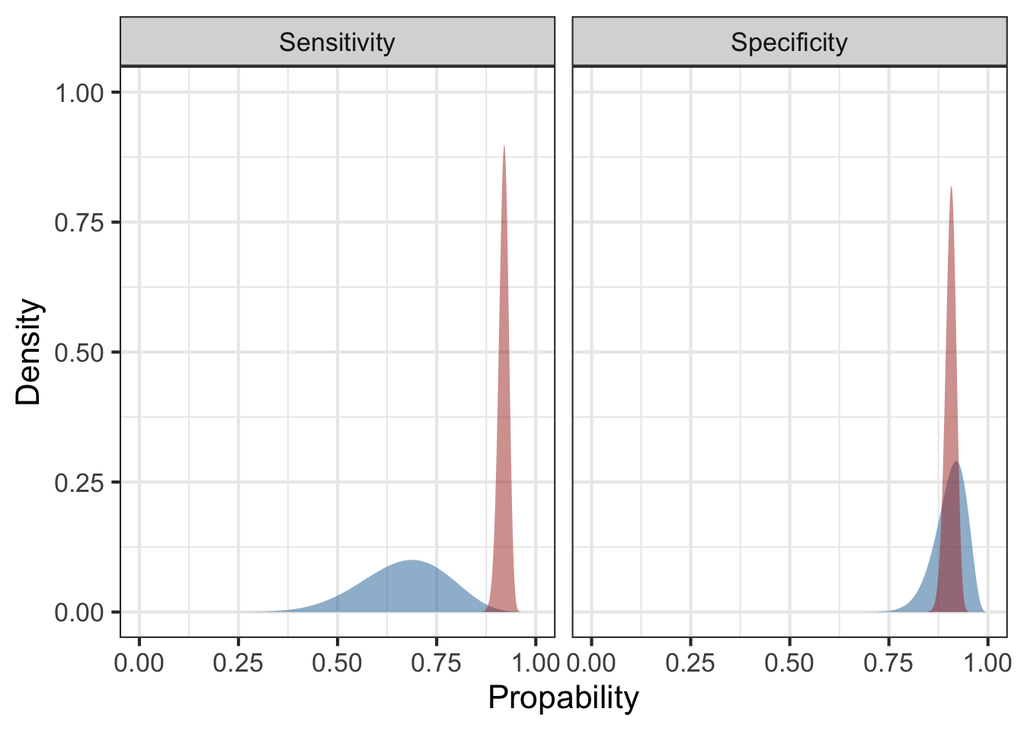

Blue density plot - prior beta distribution, red density plot - posterior beta distribution.

We used literature data on the sensitivity and specificity of the Wells test (67% and 90%, respectively). [doi: 10.1186/s13017-016-0078-1]

Figure 2. Dependence of post-test probability on prevalence.

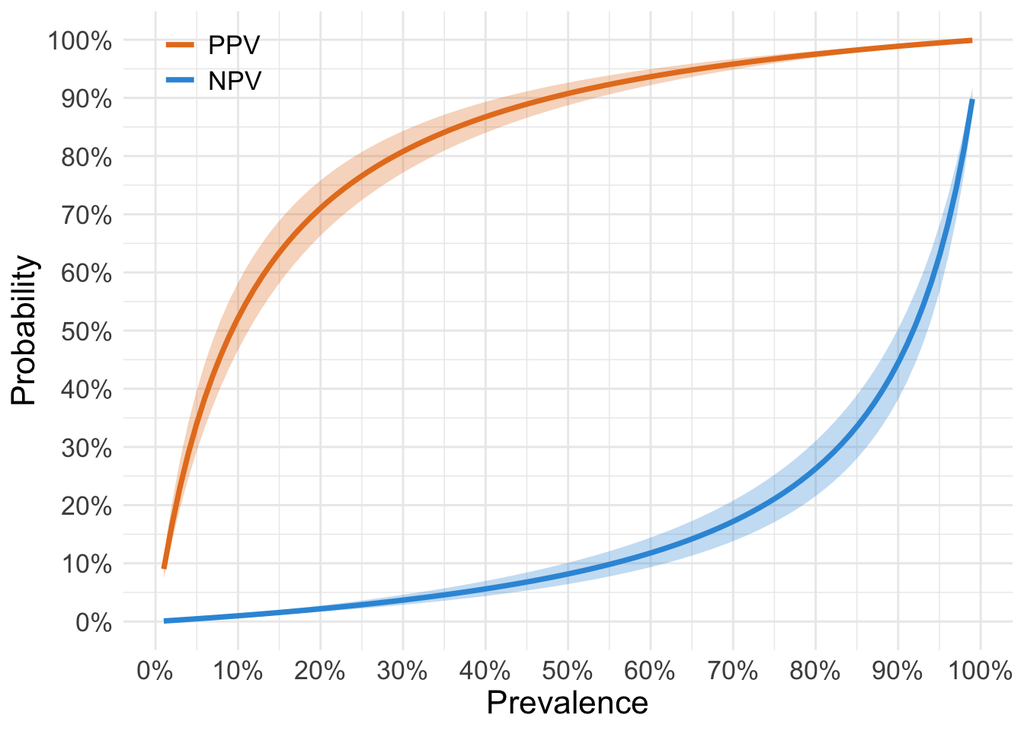

PPV - positive post-test probability. NPV - negative post-test probability. Saturated lines are a point estimate of probability, semitransparent areas are 89% credible interval.

The graph also shows that starting from about 30% of the prevalence, you can be fairly sure of a positive (gradually coming to a plateau) or negative (still on a plateau) result of the Wells test.

Table 3. Post-test probability depending on prevalence.

| Pre-test probability, % | PPV (89% CI),% | NPV (89% CI),% |
| --- | --- | --- |
| 1 | 9.02 (7.37 – 11.25) | 0.09 (0.07 – 0.11) |
| 5 | 33.88 (29.13 – 39.56) | 0.46 (0.36 – 0.58) |
| 10 | 51.92 (46.42 – 57.98) | 0.97 (0.75 – 1.22) |
| 15 | 63.15 (57.89 – 68.65) | 1.53 (1.18 – 1.92) |
| 20 | 70.80 (66.05 – 75.6) | 2.15 (1.67 – 2.7) |
| 25 | 76.36 (72.16 – 80.5) | 2.85 (2.21 – 3.57) |
| 30 | 80.58 (76.9 – 84.13) | 3.63 (2.82 – 4.54) |
| 35 | 83.89 (80.69 – 86.93) | 4.51 (3.51 – 5.63) |
| 40 | 86.56 (83.78 – 89.16) | 5.52 (4.31 – 6.87) |
| 45 | 88.75 (86.36 – 90.98) | 6.68 (5.23 – 8.29) |
| 50 | 90.76 (88.72 – 92.64) | 8.17 (6.42 – 10.13) |
| 55 | 92.43 (90.74 – 93.98) | 9.97 (7.87 – 12.27) |
| 60 | 93.74 (92.31 – 95.03) | 11.95 (9.48 – 14.63) |
| 65 | 94.87 (93.69 – 95.94) | 14.37 (11.47 – 17.49) |
| 70 | 95.87 (94.91 – 96.74) | 17.40 (13.98 – 21.01) |
| 75 | 96.76 (95.99 – 97.44) | 21.30 (17.27 – 25.46) |
| 80 | 97.55 (96.96 – 98.07) | 26.50 (21.76 – 31.28) |
| 85 | 98.25 (97.83 – 98.63) | 33.78 (28.24 – 39.18) |
| 90 | 98.89 (98.62 – 99.13) | 44.74 (38.44 – 50.55) |
| 95 | 99.47 (99.34 – 99.59) | 63.05 (56.83 – 68.3) |

PPV - positive post-test probability. NPV - negative post-test probability. CI - Credible interval. The pre-test probability corresponds to the prevalence of DVT in the population. A positive result was considered to be a value on the Wells scale of 2 points or higher.

According to the data obtained, we can say that with a prevalence of DVT in the population above 30%, one can be fairly confident in the test result, since a positive post-test probability will be about 80% (with a probability of 89%, the true result lies in the range of 77-85%), and a negative one is about 4% (true in the range of 3-5%).